## Part 1: Data Preparation

- The first step of data analysis is to prepare a data set that is easy to use.
- Once the data file `ucsbdata.csv` is downloaded, it should be converted into a data object (such as a data frame in `R`) in your program.
- Let’s import the data file:

```r
data.obj <- read.csv("ucsbdata.csv")
head(data.obj)
```

```
##        Index             R US10YR  EPS      PER  OPEN  HIGH   LOW CLOSE BDIY
## 1 1960-01-14 -0.0003883556     NA 3.39 17.22714 58.40 58.40 58.40 58.40   NA
## 2 1960-01-15 -0.0084688890     NA 3.39 17.22124 58.38 58.38 58.38 58.38   NA
## 3 1960-01-18 -0.0108042309     NA 3.39 17.07670 57.89 57.89 57.89 57.89   NA
## 4 1960-01-19 -0.0035340012     NA 3.39 16.89381 57.27 57.27 57.27 57.27   NA
## 5 1960-01-20  0.0024152839     NA 3.39 16.83481 57.07 57.07 57.07 57.07   NA
## 6 1960-01-21  0.0029382799     NA 3.39 16.87611 57.21 57.21 57.21 57.21   NA
##   VIX PCR MVOLE DXY       ASP ADVDECL FEDFUNDS NYSEADV IC  BAA NOS BER
## 1  NA  NA    NA  NA 1.0158308       0        4      NA NA 5.34  NA  NA
## 2  NA  NA    NA  NA 1.0156134       0        4      NA NA 5.34  NA  NA
## 3  NA  NA    NA  NA 1.0072196       0        4      NA NA 5.34  NA  NA
## 4  NA  NA    NA  NA 0.9965628       0        4      NA NA 5.34  NA  NA
## 5  NA  NA    NA  NA 0.9932130       0        4      NA NA 5.34  NA  NA
## 6  NA  NA    NA  NA 0.9957800       0        4      NA NA 5.34  NA  NA
##          DVY PTB  AAA   SI URR FOMC PPIR RV LOAN VVIX NAPMNEWO NAPMPRIC NAPMPMI
```

[output cut: 34 more lines]

- The function `read.csv()` reads a `csv` file and converts it into an `R` object `data.obj`. The function `head()` shows 1st 6 rows in a data object.
- One would like to change the type of the variable `Index` from factor to date:

```r
class(data.obj$Index)
```

```
## [1] "factor"
```

```r
data.obj$Index <- as.Date(data.obj$Index)
class(data.obj$Index)
```

```
## [1] "Date"
```

## Part 2: Variable and Model Selection

- The second step is to build a prediction model.
- In this example, we will see how to select a subset of a data object and then construct a simple linear model.
- Let’s assume that one would like to restrict observations to recent ones, say, from 2011 to 2017.

```r
train <- as.numeric(format(data.obj$Index, "%Y")) %in% c(2011:2017)
head(train)
```

```
## [1] FALSE FALSE FALSE FALSE FALSE FALSE
```

- `as.numeric(format(data.obj$Index, "%Y"))` returns years from a date variable and then it is compared with a set of numbers `c(2011:2017)` by `%in%` operator so that `train` is a vector of logical values, `TRUE` or `FALSE`, which indicates whether an observation belongs to the years from 2011 to 2017.
- Similarly, to test this model by predicting the values in early 2018, a test index can be assigned.

```r
test <- (as.numeric(format(data.obj$Index, "%Y")) %in% c(2018)) &
  (as.numeric(format(data.obj$Index, "%m")) %in% c(1:3))
```

- Now, let’s make a simple linear model with one predictor `US10YR`, because our econ-major crew suggested that 10-year Treasury yield might be the most important predictor of stock prices.

```r
lm.obj <- lm(R ~ US10YR, data=data.obj[train, ])
summary(lm.obj)
```

```
##
## Call:
## lm(formula = R ~ US10YR, data = data.obj[train, ])
##
## Residuals:
##        Min         1Q     Median         3Q        Max
## -0.0214698 -0.0037494  0.0000074  0.0044643  0.0203850
##
## Coefficients:
##               Estimate Std. Error t value Pr(>|t|)
## (Intercept)  0.0019694  0.0009264   2.126   0.0337 *
## US10YR      -0.0006235  0.0004044  -1.542   0.1234
## ---
## Signif. codes:  0 '***' 0.001 '**' 0.01 '*' 0.05 '.' 0.1 ' ' 1
##
## Residual standard error: 0.007901 on 1759 degrees of freedom
## Multiple R-squared:  0.001349,   Adjusted R-squared:  0.0007815
## F-statistic: 2.376 on 1 and 1759 DF,  p-value: 0.1234
```

- Here, `lm()` is a key function that creates a linear model and contains a lot of information. `R ~ US10YR` shows that the variable to be predicted is `R` and `US10YR` is the only predictor. `data=data.obj[train, ]` tells us that a data object for this regression is `data.obj` with the restriction of row dimensions to `train`.
- If someone wants to include more variables, say earnings per share `EPS`, `+ EPS` can be added to the `lm()` function.

```r
lm.obj <- lm(R ~ US10YR + EPS, data=data.obj[train, ])
summary(lm.obj)
```

```
##
## Call:
## lm(formula = R ~ US10YR + EPS, data = data.obj[train, ])
##
## Residuals:
##        Min         1Q     Median         3Q        Max
## -0.0214774 -0.0037570  0.0000085  0.0044671  0.0203831
##
## Coefficients:
##               Estimate Std. Error t value Pr(>|t|)
## (Intercept)  2.133e-03  2.476e-03   0.861    0.389
## US10YR      -6.244e-04  4.048e-04  -1.543    0.123
## EPS         -1.719e-06  2.416e-05  -0.071    0.943
##
## Residual standard error: 0.007903 on 1758 degrees of freedom
## Multiple R-squared:  0.001352,   Adjusted R-squared:  0.000216
## F-statistic:  1.19 on 2 and 1758 DF,  p-value: 0.3044
```

- Finally, a linear model can be defined using all the columns in a data object.

```r
lm.obj <- lm(R ~ ., data=data.obj[train, ])
summary(lm.obj)
```

```
##
## Call:
## lm(formula = R ~ ., data = data.obj[train, ])
##
## Residuals:
##        Min         1Q     Median         3Q        Max
## -0.0261787 -0.0039860  0.0003236  0.0045836  0.0233796
##
## Coefficients: (1 not defined because of singularities)
##                    Estimate Std. Error t value Pr(>|t|)
## (Intercept)      -4.161e-01  2.170e-01  -1.917 0.055373 .
## Index             3.084e-05  1.296e-05   2.380 0.017440 *
## US10YR            3.683e-03  3.320e-02   0.111 0.911701
## EPS              -1.208e-03  7.245e-04  -1.668 0.095581 .
## PER              -6.585e-03  3.319e-03  -1.984 0.047416 *
## OPEN              4.245e-05  4.920e-05   0.863 0.388395
## HIGH             -9.396e-05  4.884e-05  -1.924 0.054549 .
## LOW              -3.159e-06  4.741e-05  -0.067 0.946871
## CLOSE            -2.242e-04  1.954e-04  -1.147 0.251528
## BDIY              8.947e-09  1.041e-06   0.009 0.993141
## VIX              -3.311e-04  1.806e-04  -1.833 0.066963 .
## PCR              -2.786e-03  2.687e-03  -1.037 0.299972
## MVOLE             3.350e-08  8.515e-08   0.393 0.694063
## DXY              -4.997e-05  1.360e-04  -0.367 0.713294
## ASP               2.592e-03  1.718e-03   1.509 0.131478
## ADVDECL          -1.831e-03  1.765e-03  -1.038 0.299554
## FEDFUNDS         -8.292e-03  4.896e-03  -1.694 0.090528 .
## NYSEADV           8.486e-07  7.519e-07   1.129 0.259191
## IC               -2.390e-05  4.438e-05  -0.539 0.590285
## BAA              -5.871e-03  2.445e-03  -2.402 0.016431 *
## NOS              -5.756e-03  1.534e-02  -0.375 0.707479
## BER              -2.074e-03  2.272e-03  -0.913 0.361310
## DVY              -4.621e-01  1.424e+00  -0.324 0.745649
## PTB               2.811e-02  1.219e-02   2.306 0.021218 *
## AAA               3.105e-03  3.147e-03   0.987 0.323998
## SI               -6.160e-04  6.638e-04  -0.928 0.353574
## URR               5.051e-04  8.919e-04   0.566 0.571305
## FOMC              6.163e-04  1.087e-03   0.567 0.570741
## PPIR             -7.431e-04  8.778e-04  -0.847 0.397336
## RV               -1.175e-04  8.621e-05  -1.363 0.173194
```

[output cut: 29 more lines]

```
## TOM               1.621e-04  4.565e-04   0.355 0.722581
## HULBERTSENTIMENT  2.203e-05  2.197e-05   1.003 0.316067
## BUBBLE           -5.017e-05  5.591e-05  -0.897 0.369616
## CASH              1.429e-05  3.214e-05   0.445 0.656708
## DEBT             -3.877e-05  1.643e-05  -2.360 0.018383 *
## DIVIDEND          2.397e-05  3.641e-05   0.658 0.510379
## RETURN           -7.356e-05  6.462e-05  -1.138 0.255102
## STOCKS           -5.644e-06  4.036e-05  -0.140 0.888809
## WAR              -4.734e-06  3.768e-05  -0.126 0.900045
## ---
## Signif. codes:  0 '***' 0.001 '**' 0.01 '*' 0.05 '.' 0.1 ' ' 1
##
## Residual standard error: 0.007744 on 1694 degrees of freedom
## Multiple R-squared:  0.07611,    Adjusted R-squared:  0.04011
## F-statistic: 2.114 on 66 and 1694 DF,  p-value: 7.653e-07
```

## Part 3: Prediction

- The last step is to compare actual values and predicted values to evaluate the prediction model.
- Actual values can be re-defined by a new variable `y.actual` from the data object.

```r
y.actual <- data.obj[test, ]$R
head(y.actual)
```

```
## [1]  0.006251195  0.004152031  0.006587865  0.001772631  0.002205120
## [6] -0.001585978
```

- Predicted values can be computed based on a model object with the `predict()` function.

```r
y.predicted <- predict(lm.obj, newdata=data.obj[test, ])
head(y.predicted)
```

```
##         14592         14593         14594         14595         14596
## -0.0014209243 -0.0028782569 -0.0002165998 -0.0036342309 -0.0026220328
##         14597
## -0.0010901102
```

- Let’s compare them by plotting a graph!

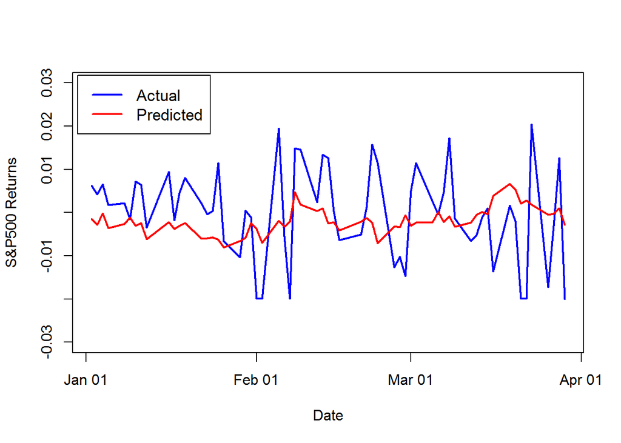

```r
plot(data.obj[test, ]$Index, y.actual, type="l", lwd=2, col="blue", ylim=c(-0.03, 0.03), xlab="Date", ylab="S&P500 Returns")
lines(data.obj[test, ]$Index, y.predicted, lwd=2, col="red")
legend("topleft", inset=0.01, legend=c("Actual", "Predicted"), col=c("blue", "red"), cex=1.1, lwd=2)
```